# FEATURE ENGINEERING

Feature Engineering adalah bagaimana kita menggunakan pengetahuan kita dalam memilih features atau membuat features baru agar model machine learning dapat bekerja lebih akurat dalam memecahkan masalah

##### STRATEGI FEATURE ENGINEERING

- Menambah atau membuang feature, pilih fitur yang signifikan mempengaruhi hasil akhir
- Menggabungkan beberapa fitur menjadi 1 fitur, agar model lebih simple. Contoh ukuran panjang dan lebar tanah, maka digabungkan menjadi 1 fitur saja, yaitu luas tanah
- Binning, yaitu mengganti angka numerikal menjadi kategori yang lebih luas, agar model lebih simple. Contoh, data ukuran kolom renang, diubah menjadi Boolean, True jika adalah kolom renang dan False jika tidak ada kolom renang
- One Hot Encoding , cara mempresentasikan data tipe kategori sebagai numerik dimana dapat dipahami model machine learning

[figure not shown]

Upload dataset berikut ini:

Santander Customer Satisfaction

Telco Customer Churn

Kondisi Ekstrim

1. High Bias
- *Sebab*
  - Penggunaan fitur sangat sedikit (Oversimplified)
- *Akibat*
  - Error besar pada training set
1. High Variance
- *Sebab*
  - Penggunaan fitur terlalu banyak (Overfits)
- *Akibat*
  - Error lebih besar pada test set dibandingkan training set (tidak mampu merespon data baru dengan baik)

Tujuan Feature Engineering

- Meningkatkan kecepatan training model
- Mengurangi overfitting
- Mengurangi kompleksitas model
- Meningkatkan akurasi model

# FILTER FEATURE SELECTION

Bagaimana cara memilih fitur dan apa Manfaat melakukan pemilihan fitur sebelum memodelkan data Anda?

- Mengurangi Overfitting: Data yang lebih sedikit berarti lebih sedikit kesempatan untuk membuat keputusan
- Meningkatkan Akurasi: Data yang kurang improve berarti akurasi pemodelan meningkat.
- Mengurangi Waktu Pelatihan: Lebih sedikit titik data mengurangi kompleksitas algoritme dan algoritme melatih lebih cepat.
1. FILTER METHOD

Filter univariat mengevaluasi dan memberi peringkat satu fitur menurut kriteria tertentu, sedangkan filter multivarian mengevaluasi seluruh ruang fitur. Metode filter adalah:

- Memilih variabel terlepas dari modelnya
- Lebih cepat secara komputasi
- Biasanya memberikan kinerja prediksi yang lebih rendah
- Metode filter meranking fitur berdasarkan relevansinya dengan kelas target. Umumnya digunakan sebagai langkah preprocessing.
- Tidak bergantung pada algoritma machine learning apapun. Oleh karena itu, fitur dipilih berdasarkan skor dari uji statistik dengan menghitung korelasi antara fitur dan variabel hasil (prediksi)
- *Kelebihan* = Metode filter lebih cepat dikomputasi dan tahan terhadap overfitting
- *Kekurangan* = Namun, metode filter cenderung lebih sering memilih fitur-fitur redundan yang dapat berdampak pada akurasi

### 1. KORELASI

#### RUMUS

[figure not shown]

#### Multikolinearitas

Multokollinearitas adalah konsep statistik dimana variabel independen dalam suatu model dikorelasikan. Multikolinearitas antar variabel independen akan menghasilkan inferensi statistik yang kurang reliabel. Sebaiknya gunakan variabel independen yang tidak berkorelasi atau berulang ketika membangun model regresi berganda yang menggunakan dua variabel atau lebih.

Analis statistik menggunakan model regresi berganda untuk memprediksi nilai variabel dependen tertentu berdasarkan nilai dua atau lebih variabel independen. Variabel dependen kadang-kadang disebut sebagai variabel hasil, target, atau kriteria.

Contohnya adalah model regresi multivariat yang mencoba mengantisipasi pengembalian saham berdasarkan item seperti rasio harga terhadap pendapatan (rasio P/E), kapitalisasi pasar, kinerja masa lalu, atau data lainnya.

```python
import pandas as pd
from sklearn.model_selection import train_test_split
```

```python
df=pd.read_csv('train.csv',nrows=10000)
```

```python
X=df.drop(labels=['TARGET'], axis=1)
y=df['TARGET']
```

```python
X_train, X_test, y_train, y_test = train_test_split(X, y, test_size=0.3, random_state=0)
X_train.shape, X_test.shape
```

```
((7000, 370), (3000, 370))
```

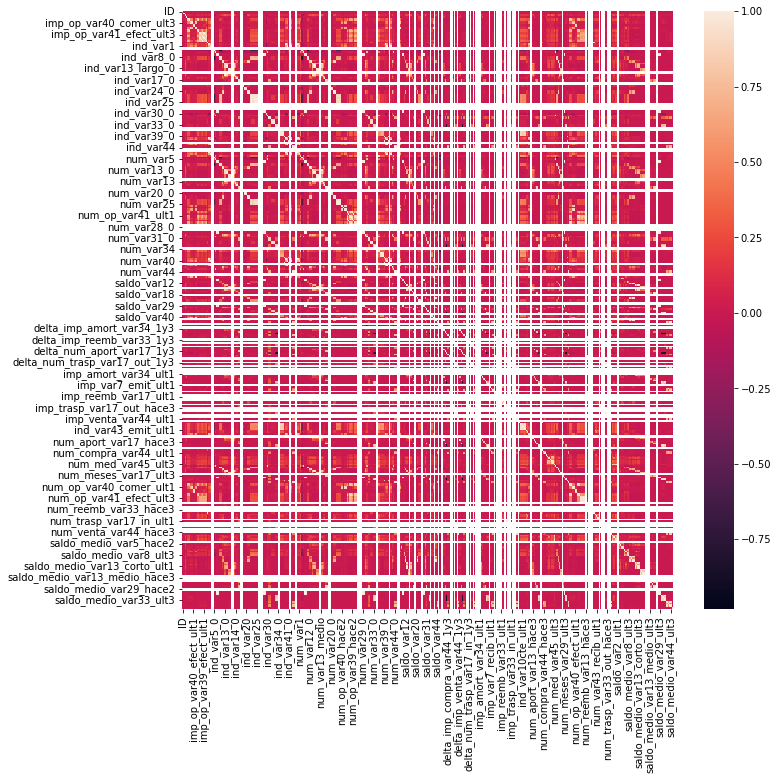

```python
import seaborn as sns
import matplotlib.pyplot as plt
#Using Pearson Correlation
fig, ax = plt.subplots()
fig.set_size_inches(11,11)
sns.heatmap(X_train.corr())
```

```python
# with the following function we can select highly correlated features
# it will remove the first feature that is correlated with anything other feature

def correlation(dataset, threshold):
    col_corr = set()  # Set of all the names of correlated columns
    corr_matrix = dataset.corr()
    for i in range(len(corr_matrix.columns)):
        for j in range(i):
            if abs(corr_matrix.iloc[i, j]) > threshold: # we are interested in absolute coeff value
                colname = corr_matrix.columns[i]  # getting the name of column
                col_corr.add(colname)
    return col_corr
```

```python
corr_features = correlation(X_train, 0.7)
len(set(corr_features))
```

```
216
```

```python
corr_features
```

```
{'delta_imp_aport_var17_1y3',
 'delta_imp_aport_var33_1y3',
 'delta_imp_compra_var44_1y3',
 'delta_imp_venta_var44_1y3',
 'delta_num_aport_var13_1y3',
 'delta_num_aport_var17_1y3',
 'delta_num_aport_var33_1y3',
 'delta_num_compra_var44_1y3',
 'delta_num_reemb_var13_1y3',
 'delta_num_trasp_var17_in_1y3',
 'delta_num_trasp_var33_in_1y3',
 'delta_num_venta_var44_1y3',
 'imp_aport_var13_ult1',
 'imp_aport_var17_ult1',
 'imp_aport_var33_hace3',
 'imp_aport_var33_ult1',
 'imp_compra_var44_ult1',
 'imp_op_var39_comer_ult3',
 'imp_op_var39_efect_ult1',
 'imp_op_var39_efect_ult3',
 'imp_op_var39_ult1',
 'imp_op_var40_comer_ult3',
 'imp_op_var40_efect_ult3',
 'imp_op_var40_ult1',
 'imp_op_var41_comer_ult1',
 'imp_op_var41_comer_ult3',
 'imp_op_var41_efect_ult3',
 'imp_op_var41_ult1',
 'imp_reemb_var13_ult1',
 'imp_trans_var37_ult1',
 'imp_trasp_var17_in_ult1',
 'imp_trasp_var33_in_ult1',
 'imp_venta_var44_ult1',
 'ind_var10_ult1',
 'ind_var10cte_ult1',
 'ind_var12',
 'ind_var13',
 'ind_var13_corto',
 'ind_var13_corto_0',
 'ind_var13_largo',
```

[output cut: 161 more lines]

```
 'saldo_var13_corto',
 'saldo_var13_largo',
 'saldo_var17',
 'saldo_var24',
 'saldo_var25',
 'saldo_var29',
 'saldo_var30',
 'saldo_var31',
 'saldo_var32',
 'saldo_var33',
 'saldo_var40',
 'saldo_var42',
 'saldo_var44',
 'saldo_var6',
 'var21'}
```

```python
X_train.drop(corr_features,axis=1)
```

|  | ID | var3 | var15 | imp_ent_var16_ult1 | imp_op_var39_comer_ult1 | imp_op_var40_comer_ult1 | imp_op_var40_efect_ult1 | imp_op_var41_efect_ult1 | imp_sal_var16_ult1 | ind_var1_0 | ... | saldo_medio_var8_hace3 | saldo_medio_var12_hace3 | saldo_medio_var13_medio_hace2 | saldo_medio_var13_medio_hace3 | saldo_medio_var13_medio_ult1 | saldo_medio_var13_medio_ult3 | saldo_medio_var17_hace2 | saldo_medio_var29_hace2 | saldo_medio_var29_hace3 | var38 |
| --- | --- | --- | --- | --- | --- | --- | --- | --- | --- | --- | --- | --- | --- | --- | --- | --- | --- | --- | --- | --- | --- |
| 7681 | 15431 | 2 | 42 | 840.0 | 4477.02 | 0.0 | 0 | 0.0 | 0 | 0 | ... | 0.0 | 0.0 | 0 | 0 | 0 | 0 | 0.0 | 0.0 | 0 | 37491.21 |
| 9031 | 18181 | 2 | 31 | 0.0 | 52.32 | 0.0 | 0 | 0.0 | 0 | 0 | ... | 0.0 | 0.0 | 0 | 0 | 0 | 0 | 0.0 | 0.0 | 0 | 106685.94 |
| 3691 | 7411 | 2 | 51 | 0.0 | 0.00 | 0.0 | 0 | 0.0 | 0 | 0 | ... | 0.0 | 0.0 | 0 | 0 | 0 | 0 | 0.0 | 0.0 | 0 | 66144.66 |
| 202 | 407 | 2 | 36 | 0.0 | 0.00 | 0.0 | 0 | 0.0 | 0 | 0 | ... | 0.0 | 0.0 | 0 | 0 | 0 | 0 | 0.0 | 0.0 | 0 | 92121.36 |
| 5625 | 11280 | 2 | 23 | 0.0 | 0.00 | 0.0 | 0 | 0.0 | 0 | 0 | ... | 0.0 | 0.0 | 0 | 0 | 0 | 0 | 0.0 | 0.0 | 0 | 74650.83 |
| ... | ... | ... | ... | ... | ... | ... | ... | ... | ... | ... | ... | ... | ... | ... | ... | ... | ... | ... | ... | ... | ... |
| 9225 | 18564 | 2 | 33 | 0.0 | 0.00 | 0.0 | 0 | 0.0 | 0 | 0 | ... | 0.0 | 0.0 | 0 | 0 | 0 | 0 | 0.0 | 0.0 | 0 | 117547.89 |
| 4859 | 9723 | 2 | 24 | 0.0 | 0.00 | 0.0 | 0 | 0.0 | 0 | 0 | ... | 0.0 | 0.0 | 0 | 0 | 0 | 0 | 0.0 | 0.0 | 0 | 71050.83 |
| 3264 | 6557 | 2 | 24 | 0.0 | 0.00 | 0.0 | 0 | 0.0 | 0 | 0 | ... | 0.0 | 0.0 | 0 | 0 | 0 | 0 | 0.0 | 0.0 | 0 | 141069.33 |
| 9845 | 19796 | 2 | 38 | 0.0 | 0.00 | 0.0 | 0 | 150.0 | 0 | 0 | ... | 0.0 | 0.0 | 0 | 0 | 0 | 0 | 0.0 | 0.0 | 0 | 86412.15 |
| 2732 | 5441 | 2 | 23 | 0.0 | 0.00 | 0.0 | 0 | 0.0 | 0 | 0 | ... | 0.0 | 0.0 | 0 | 0 | 0 | 0 | 0.0 | 0.0 | 0 | 45985.68 |

7000 rows × 154 columns

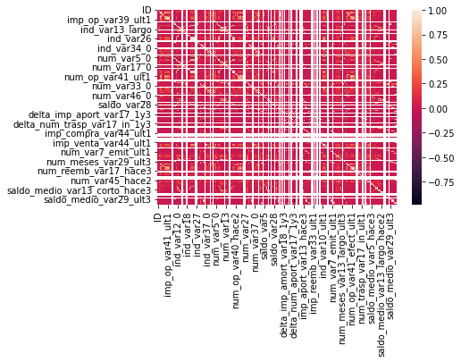

```python
sns.heatmap(X_train.corr())
```

### 2. MUTUAL INFORMATION

1. Mutual Information (MI) adalah ukuran antara dua (mungkin multi-dimensi) variabel acak X dan Y, yang mengkuantifikasi jumlah informasi yang diperoleh tentang satu variabel acak, melalui variabel acak lainnya
2. Mutual Information (MI) merupakan salah satu metode seleksi yang menunjukkan seberapa banyak informasi ada atau tidaknya sebuah term (istilah) memberikan kontribusi dalam membuat keputusan klasifikasi secara benar atau salah.

Keuntungan menggunakan Mutual Information sebagai feature selection yaitu MI merupakan model yang netral, dimana hasil dari solusi bisa diaplikasikan kedalam berbagai model machine learning. MI merupakan solusi yang cepat

Supervised feature selection adalah metode seleksi fitur yang menggunakan informasi kelas dalam data latih, sehingga untuk menggunakan seleksi fitur ini harus tersedia sebuah set pre-classied Garnes, 2009. Mutual Information adalah contoh dari supervised feature selection. Fitur seleksi ini sering digunakan untuk menghitung bobot dari fitur. Mutual Information menunjukkan seberapa banyak informasi ada atau tidaknya sebuah term memberikan kontribusi dalam membuat keputusan klasifikasi secara benar atau salah

Rumus Persamaan (1)

[figure not shown]

Rumus Persamaan (2)

Pada domain diskrit, nilai dari Mutual Information antara dua variabel acak didefinisikan sebagai berikut:

[figure not shown]

Rumus Persamaan (3)

[figure not shown]

```python
import pandas as pd
from sklearn.feature_selection import mutual_info_classif
#Regression
#from sklearn.feature_selection import mutual_info_regression
```

```python
df=pd.read_csv('train.csv',nrows=10000)
```

```python
X=df.drop(labels=['TARGET'], axis=1)
y=df['TARGET']
```

```python
from sklearn.model_selection import train_test_split

X_train, X_test, y_train, y_test = train_test_split(X, y, test_size=0.3, random_state=0)
X_train.shape, X_test.shape
```

```
((7000, 370), (3000, 370))
```

```python
mutual_info = mutual_info_classif(X_train, y_train)
mutual_info
```

```
array([2.16341646e-03, 0.00000000e+00, 1.14123632e-02, 0.00000000e+00,
       3.36047937e-03, 0.00000000e+00, 0.00000000e+00, 0.00000000e+00,
       7.09758208e-04, 0.00000000e+00, 0.00000000e+00, 1.24449851e-04,
       0.00000000e+00, 1.87645385e-03, 0.00000000e+00, 1.71878085e-03,
       2.72038716e-03, 0.00000000e+00, 1.83214429e-03, 0.00000000e+00,
       3.23303911e-03, 0.00000000e+00, 0.00000000e+00, 0.00000000e+00,
       5.09603994e-03, 9.52871055e-03, 0.00000000e+00, 0.00000000e+00,
       1.94571032e-03, 1.55575098e-03, 2.84353110e-03, 1.81125582e-03,
       0.00000000e+00, 0.00000000e+00, 1.03310686e-03, 1.10822859e-03,
       3.82763814e-03, 1.59742662e-03, 0.00000000e+00, 1.95528544e-03,
       0.00000000e+00, 1.87057007e-03, 0.00000000e+00, 0.00000000e+00,
       2.29840621e-03, 0.00000000e+00, 0.00000000e+00, 2.68899880e-03,
       7.70681924e-05, 2.93159452e-03, 0.00000000e+00, 3.00139767e-03,
       7.17690435e-03, 2.81221377e-03, 1.29186263e-04, 2.91279607e-03,
       0.00000000e+00, 0.00000000e+00, 5.48629976e-04, 0.00000000e+00,
       0.00000000e+00, 0.00000000e+00, 3.00909825e-03, 4.60798506e-03,
       5.69288145e-03, 0.00000000e+00, 1.83629898e-03, 9.14288886e-04,
       0.00000000e+00, 4.16548598e-05, 2.36451815e-03, 4.70862633e-04,
       4.31161609e-05, 1.10173614e-04, 5.28912851e-04, 4.23267530e-03,
       0.00000000e+00, 2.95469590e-03, 1.09302329e-03, 2.10983481e-03,
       0.00000000e+00, 3.33297668e-03, 3.07863767e-03, 0.00000000e+00,
       1.15899030e-03, 0.00000000e+00, 9.64784269e-04, 0.00000000e+00,
       0.00000000e+00, 7.98786935e-03, 0.00000000e+00, 4.18976759e-03,
       0.00000000e+00, 0.00000000e+00, 3.53496752e-03, 0.00000000e+00,
       1.01349287e-03, 1.11035173e-03, 0.00000000e+00, 7.45918321e-03,
       2.57777468e-03, 0.00000000e+00, 3.18156885e-03, 1.31020332e-04,
       0.00000000e+00, 0.00000000e+00, 3.25209516e-04, 1.03182101e-03,
       1.21707346e-03, 1.09579106e-04, 0.00000000e+00, 0.00000000e+00,
       7.42861836e-04, 2.07976311e-03, 8.46411900e-04, 1.18558327e-03,
       0.00000000e+00, 0.00000000e+00, 1.66917055e-03, 2.22266735e-03,
       0.00000000e+00, 1.22907045e-03, 0.00000000e+00, 0.00000000e+00,
       0.00000000e+00, 1.69748005e-03, 0.00000000e+00, 0.00000000e+00,
       2.81376980e-03, 0.00000000e+00, 0.00000000e+00, 0.00000000e+00,
       0.00000000e+00, 0.00000000e+00, 0.00000000e+00, 0.00000000e+00,
       0.00000000e+00, 0.00000000e+00, 5.98759263e-03, 7.62839835e-03,
       2.11256866e-03, 0.00000000e+00, 4.38434779e-03, 9.37136179e-04,
       2.47522614e-03, 2.49652028e-03, 0.00000000e+00, 7.13812047e-05,
       5.89570007e-03, 0.00000000e+00, 1.20472893e-03, 1.77121992e-03,
       5.12584846e-04, 1.01864367e-03, 0.00000000e+00, 0.00000000e+00,
       0.00000000e+00, 3.75830395e-03, 1.13657476e-04, 6.94358085e-03,
```

[output cut: 38 more lines]

```
       0.00000000e+00, 1.22466566e-03, 1.88543110e-04, 0.00000000e+00,
       0.00000000e+00, 0.00000000e+00, 2.89590083e-03, 8.11875443e-04,
       0.00000000e+00, 5.20886535e-04, 1.44724784e-04, 2.52740121e-03,
       2.96393803e-03, 1.63008756e-03, 1.55695453e-03, 1.49829470e-03,
       1.04472602e-03, 6.45855934e-03, 7.77380922e-03, 7.78202874e-03,
       1.02132377e-02, 2.34782429e-03, 0.00000000e+00, 8.19434500e-04,
       1.99418860e-03, 2.63826957e-03, 2.78789903e-03, 0.00000000e+00,
       0.00000000e+00, 6.82107031e-03, 2.22123899e-04, 1.48745388e-03,
       1.56728699e-03, 1.68270764e-03, 2.51152699e-03, 9.23051455e-04,
       3.43870329e-03, 0.00000000e+00, 0.00000000e+00, 0.00000000e+00,
       0.00000000e+00, 1.41137315e-03, 1.55803770e-03, 0.00000000e+00,
       0.00000000e+00, 1.44412587e-03, 0.00000000e+00, 0.00000000e+00,
       2.21388568e-03, 0.00000000e+00, 0.00000000e+00, 2.57230632e-03,
       0.00000000e+00, 0.00000000e+00, 0.00000000e+00, 0.00000000e+00,
       4.42353084e-04, 2.63973921e-03])
```

```python
mutual_info = pd.Series(mutual_info)
mutual_info.index = X_train.columns
mutual_info.sort_values(ascending=False)
```

```
var15                    0.011412
saldo_var30              0.011322
saldo_var42              0.010850
saldo_medio_var5_ult3    0.010213
num_meses_var5_ult3      0.009623
                           ...
num_var44_0              0.000000
ind_var13_medio          0.000000
num_var2_0_ult1          0.000000
num_var41                0.000000
ind_var29_0              0.000000
Length: 370, dtype: float64
```

```python
mutual_info[mutual_info == 0]
```

```
var3                       0.0
imp_ent_var16_ult1         0.0
imp_op_var39_comer_ult3    0.0
imp_op_var40_comer_ult1    0.0
imp_op_var40_comer_ult3    0.0
                          ...
saldo_medio_var33_hace3    0.0
saldo_medio_var33_ult3     0.0
saldo_medio_var44_hace2    0.0
saldo_medio_var44_hace3    0.0
saldo_medio_var44_ult1     0.0
Length: 161, dtype: float64
```

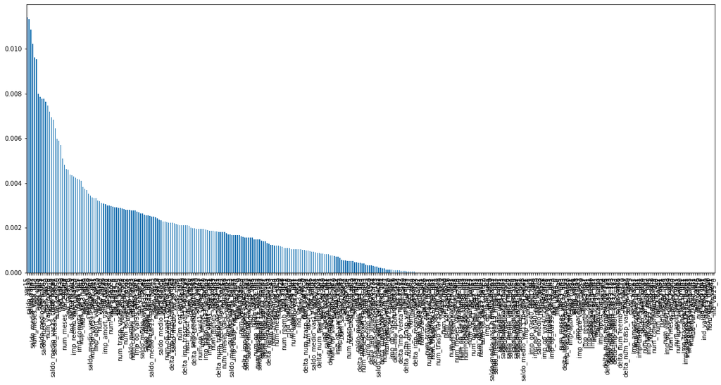

```python
# Plot mutual info dari masing-masing fitur
mutual_info.sort_values(ascending=False).plot.bar(figsize=(20, 8))
```

### 3. VARIANCE THRESHOLD

Pemilih fitur yang menghapus semua fitur varian rendah.

Algoritma pemilihan fitur ini hanya melihat pada fitur (X), bukan output yang diinginkan (y), dan dengan demikian dapat digunakan untuk unsupervised learning

Variance Threshold adalah pendekatan dasar sederhana untuk pemilihan fitur. Dengan menghapus semua fitur yang variansnya tidak memenuhi ambang batas tertentu. Secara default, ini menghapus semua fitur zero-variance, yaitu fitur yang memiliki nilai yang sama di semua sampel

Variance Threshold sendiri merupakan merupakan varians atau ragam suatu peubah acak (atau distribusi probabilitas) adalah ukuran seberapa jauh sebuah kumpulan bilangan tersebar. Varians nol mengindikasikan bahwa semua nilai sama. Varians selalu bernilai non-negatif: varians yang rendah mengindikasikan bahwa titik data condong sangat dekat dengan nilai rerata (nilai ekspektasi) dan antara satu sama lainnya, sementara varians yang tinggi mengindikasikan bahwa titik data sangat tersebar disekitar rerata dan dari satu sama lainnya.(Sumber :wikipedia). Berdasarkan pengertian tersebut varian yang nilai mendekati nol pasti memiliki kemiripan yang hampir sama persis. Artinya jika data hampir mirip maka untuk membedakan satu label dengan label yang lain akhirnya fitur yang memiliki nilai varian yang hampir 0 (datanya mirip) akan menyebabkan bias pada pemodelan yang dibuat dikarenakan nilai yang hampir sama.

```python
import pandas as pd
from sklearn.feature_selection import VarianceThreshold
```

```python
df=pd.read_csv('train.csv',nrows=10000)
```

```python
df.shape
```

```
(10000, 371)
```

```python
df.head()
```

|  | ID | var3 | var15 | imp_ent_var16_ult1 | imp_op_var39_comer_ult1 | imp_op_var39_comer_ult3 | imp_op_var40_comer_ult1 | imp_op_var40_comer_ult3 | imp_op_var40_efect_ult1 | imp_op_var40_efect_ult3 | ... | saldo_medio_var33_hace2 | saldo_medio_var33_hace3 | saldo_medio_var33_ult1 | saldo_medio_var33_ult3 | saldo_medio_var44_hace2 | saldo_medio_var44_hace3 | saldo_medio_var44_ult1 | saldo_medio_var44_ult3 | var38 | TARGET |
| --- | --- | --- | --- | --- | --- | --- | --- | --- | --- | --- | --- | --- | --- | --- | --- | --- | --- | --- | --- | --- | --- |
| 0 | 1 | 2 | 23 | 0.0 | 0.0 | 0.0 | 0.0 | 0.0 | 0 | 0 | ... | 0.0 | 0.0 | 0.0 | 0.0 | 0.0 | 0.0 | 0.0 | 0.0 | 39205.170000 | 0 |
| 1 | 3 | 2 | 34 | 0.0 | 0.0 | 0.0 | 0.0 | 0.0 | 0 | 0 | ... | 0.0 | 0.0 | 0.0 | 0.0 | 0.0 | 0.0 | 0.0 | 0.0 | 49278.030000 | 0 |
| 2 | 4 | 2 | 23 | 0.0 | 0.0 | 0.0 | 0.0 | 0.0 | 0 | 0 | ... | 0.0 | 0.0 | 0.0 | 0.0 | 0.0 | 0.0 | 0.0 | 0.0 | 67333.770000 | 0 |
| 3 | 8 | 2 | 37 | 0.0 | 195.0 | 195.0 | 0.0 | 0.0 | 0 | 0 | ... | 0.0 | 0.0 | 0.0 | 0.0 | 0.0 | 0.0 | 0.0 | 0.0 | 64007.970000 | 0 |
| 4 | 10 | 2 | 39 | 0.0 | 0.0 | 0.0 | 0.0 | 0.0 | 0 | 0 | ... | 0.0 | 0.0 | 0.0 | 0.0 | 0.0 | 0.0 | 0.0 | 0.0 | 117310.979016 | 0 |

5 rows × 371 columns

```python
X=df.drop(labels=['TARGET'], axis=1)
y=df['TARGET']
```

```python
from sklearn.model_selection import train_test_split
# separate dataset into train and test
X_train, X_test, y_train, y_test = train_test_split(X, y, test_size=0.3, random_state=0)
X_train.shape, X_test.shape
```

```
((7000, 370), (3000, 370))
```

```python
var_thres=VarianceThreshold(threshold=0)
var_thres.fit(X_train)
```

```
VarianceThreshold(threshold=0)
```

```python
var_thres.get_support()
```

```
array([ True,  True,  True,  True,  True,  True,  True,  True,  True,
        True,  True,  True,  True,  True,  True,  True,  True,  True,
        True,  True,  True,  True, False, False,  True,  True,  True,
        True,  True,  True,  True,  True,  True,  True,  True,  True,
        True, False, False,  True,  True,  True,  True,  True, False,
       False,  True,  True,  True,  True,  True,  True,  True,  True,
        True,  True,  True, False, False, False, False,  True,  True,
        True,  True,  True,  True,  True,  True,  True,  True,  True,
       False, False,  True,  True,  True,  True,  True,  True,  True,
       False,  True,  True,  True, False, False,  True,  True,  True,
        True,  True,  True,  True,  True,  True,  True,  True,  True,
        True,  True,  True,  True, False, False,  True,  True,  True,
        True,  True, False, False,  True,  True,  True,  True,  True,
        True,  True,  True,  True,  True,  True,  True,  True,  True,
        True,  True,  True,  True,  True,  True, False, False, False,
       False,  True,  True,  True,  True,  True,  True,  True,  True,
        True,  True, False, False,  True,  True,  True,  True,  True,
        True,  True,  True, False,  True,  True,  True,  True,  True,
       False, False,  True,  True,  True,  True,  True,  True,  True,
       False,  True,  True,  True, False,  True,  True,  True,  True,
       False, False,  True,  True,  True,  True,  True, False,  True,
        True, False,  True,  True, False,  True, False, False,  True,
        True,  True,  True,  True, False, False,  True, False,  True,
       False,  True,  True,  True,  True,  True,  True, False, False,
        True, False,  True, False,  True, False, False, False, False,
        True,  True,  True,  True,  True,  True, False,  True,  True,
        True, False,  True, False, False, False, False,  True,  True,
       False,  True, False, False, False,  True, False, False, False,
        True, False,  True,  True,  True,  True,  True,  True,  True,
        True, False, False,  True,  True,  True,  True,  True,  True,
       False,  True,  True,  True,  True,  True,  True,  True,  True,
        True,  True,  True,  True,  True,  True,  True, False,  True,
        True,  True,  True,  True,  True,  True,  True,  True,  True,
        True,  True,  True,  True,  True,  True,  True, False,  True,
       False, False, False, False,  True,  True,  True,  True, False,
        True, False, False, False,  True, False, False, False,  True,
        True,  True,  True,  True, False,  True,  True,  True,  True,
        True,  True,  True,  True,  True,  True,  True,  True,  True,
        True,  True,  True,  True,  True,  True,  True, False, False,
       False, False,  True,  True,  True,  True, False, False,  True,
        True,  True,  True,  True,  True,  True,  True,  True,  True,
        True])
```

```python
### Finding non constant features
### True berarti data yang thresholdnya lebih dari 0
sum(var_thres.get_support())
```

```
284
```

```python
# Lets Find non-constant features
len(X_train.columns[var_thres.get_support()])
```

```
284
```

```python
#constant columns dibuang dikarenakan memiliki variance threshold terkecil
constant_columns = [column for column in X_train.columns
                    if column not in X_train.columns[var_thres.get_support()]]

print(len(constant_columns))
```

```
86
```

```python
for column in constant_columns:
    print(column)
```

```
ind_var2_0
ind_var2
ind_var13_medio_0
ind_var13_medio
ind_var18_0
ind_var18
ind_var27_0
ind_var28_0
ind_var28
ind_var27
ind_var34_0
ind_var34
ind_var41
ind_var46_0
ind_var46
num_var13_medio_0
num_var13_medio
num_var18_0
num_var18
num_var27_0
num_var28_0
num_var28
num_var27
num_var34_0
num_var34
num_var41
num_var46_0
num_var46
saldo_var13_medio
saldo_var18
saldo_var28
saldo_var27
saldo_var34
saldo_var41
saldo_var46
delta_imp_amort_var18_1y3
delta_imp_amort_var34_1y3
delta_imp_reemb_var17_1y3
delta_imp_reemb_var33_1y3
delta_imp_trasp_var17_out_1y3
```

[output cut: 31 more lines]

```
num_reemb_var33_ult1
num_trasp_var17_in_hace3
num_trasp_var17_out_hace3
num_trasp_var17_out_ult1
num_trasp_var33_in_hace3
num_trasp_var33_out_hace3
num_trasp_var33_out_ult1
num_venta_var44_hace3
saldo_var2_ult1
saldo_medio_var13_medio_hace2
saldo_medio_var13_medio_hace3
saldo_medio_var13_medio_ult1
saldo_medio_var13_medio_ult3
saldo_medio_var29_hace2
saldo_medio_var29_hace3
```

```python
X_train.drop(constant_columns,axis=1)
```

|  | ID | var3 | var15 | imp_ent_var16_ult1 | imp_op_var39_comer_ult1 | imp_op_var39_comer_ult3 | imp_op_var40_comer_ult1 | imp_op_var40_comer_ult3 | imp_op_var40_efect_ult1 | imp_op_var40_efect_ult3 | ... | saldo_medio_var29_ult3 | saldo_medio_var33_hace2 | saldo_medio_var33_hace3 | saldo_medio_var33_ult1 | saldo_medio_var33_ult3 | saldo_medio_var44_hace2 | saldo_medio_var44_hace3 | saldo_medio_var44_ult1 | saldo_medio_var44_ult3 | var38 |
| --- | --- | --- | --- | --- | --- | --- | --- | --- | --- | --- | --- | --- | --- | --- | --- | --- | --- | --- | --- | --- | --- |
| 7681 | 15431 | 2 | 42 | 840.0 | 4477.02 | 4989.54 | 0.0 | 0.0 | 0 | 0 | ... | 0.0 | 0.0 | 0.0 | 0.0 | 0.0 | 0.0 | 0.0 | 0.0 | 0.0 | 37491.21 |
| 9031 | 18181 | 2 | 31 | 0.0 | 52.32 | 52.32 | 0.0 | 0.0 | 0 | 0 | ... | 0.0 | 0.0 | 0.0 | 0.0 | 0.0 | 0.0 | 0.0 | 0.0 | 0.0 | 106685.94 |
| 3691 | 7411 | 2 | 51 | 0.0 | 0.00 | 0.00 | 0.0 | 0.0 | 0 | 0 | ... | 0.0 | 0.0 | 0.0 | 0.0 | 0.0 | 0.0 | 0.0 | 0.0 | 0.0 | 66144.66 |
| 202 | 407 | 2 | 36 | 0.0 | 0.00 | 0.00 | 0.0 | 0.0 | 0 | 0 | ... | 0.0 | 0.0 | 0.0 | 0.0 | 0.0 | 0.0 | 0.0 | 0.0 | 0.0 | 92121.36 |
| 5625 | 11280 | 2 | 23 | 0.0 | 0.00 | 0.00 | 0.0 | 0.0 | 0 | 0 | ... | 0.0 | 0.0 | 0.0 | 0.0 | 0.0 | 0.0 | 0.0 | 0.0 | 0.0 | 74650.83 |
| ... | ... | ... | ... | ... | ... | ... | ... | ... | ... | ... | ... | ... | ... | ... | ... | ... | ... | ... | ... | ... | ... |
| 9225 | 18564 | 2 | 33 | 0.0 | 0.00 | 0.00 | 0.0 | 0.0 | 0 | 0 | ... | 0.0 | 0.0 | 0.0 | 0.0 | 0.0 | 0.0 | 0.0 | 0.0 | 0.0 | 117547.89 |
| 4859 | 9723 | 2 | 24 | 0.0 | 0.00 | 0.00 | 0.0 | 0.0 | 0 | 0 | ... | 0.0 | 0.0 | 0.0 | 0.0 | 0.0 | 0.0 | 0.0 | 0.0 | 0.0 | 71050.83 |
| 3264 | 6557 | 2 | 24 | 0.0 | 0.00 | 0.00 | 0.0 | 0.0 | 0 | 0 | ... | 0.0 | 0.0 | 0.0 | 0.0 | 0.0 | 0.0 | 0.0 | 0.0 | 0.0 | 141069.33 |
| 9845 | 19796 | 2 | 38 | 0.0 | 0.00 | 0.00 | 0.0 | 0.0 | 0 | 0 | ... | 0.0 | 0.0 | 0.0 | 0.0 | 0.0 | 0.0 | 0.0 | 0.0 | 0.0 | 86412.15 |
| 2732 | 5441 | 2 | 23 | 0.0 | 0.00 | 0.00 | 0.0 | 0.0 | 0 | 0 | ... | 0.0 | 0.0 | 0.0 | 0.0 | 0.0 | 0.0 | 0.0 | 0.0 | 0.0 | 45985.68 |

7000 rows × 284 columns

### 4. STATISTICAL SIGNIFICANCE (CHI SQUARE DAN CRAMERS V)

```python
import pandas as pd
from pandas.api.types import is_numeric_dtype
import scipy.stats as stats
import numpy as np
pd.set_option('mode.chained_assignment', None)

class AttributeRelevance():
    def seq_palette(self, n_colors):
        return sns.cubehelix_palette(n_colors, start=.5, rot=-.75, reverse=True)

    def bulk_iv(self, feats, iv, woe_extremes=False):
        iv_dict = {}
        for f in feats:
            iv_df, iv_value = iv.calculate_iv(f)
            if woe_extremes:
                iv_dict[f.feature] = [iv_value, iv_df['woe'].min(), iv_df['woe'].max()]
                cols = ['iv', 'woe_min', 'woe_max']
            else:
                iv_dict[f.feature] = iv_value
                cols = ['iv']
        df = pd.DataFrame.from_dict(iv_dict, orient='index', columns=cols)
        return df

    def bulk_stats(self, feats, s):
        stats_dict = {}
        for f in feats:
            p_value, effect_size = s.calculate_chi(f)
            stats_dict[f.feature] = [p_value, effect_size]
        df = pd.DataFrame.from_dict(stats_dict, orient='index', columns=['p-value', 'effect_size'])
        return df

    def analyze(self, feats, iv, s=None, interpretation=False):
        df_iv = self.bulk_iv(feats, iv).sort_values(by='iv', ascending=False)
        if s is not None:
            df_stats = self.bulk_stats(feats, s)
            df_iv = df_iv.merge(df_stats, left_index=True, right_index=True)
        if interpretation:
            df_iv['iv_interpretation'] = df_iv['iv'].apply(iv.interpretation)
            if s is not None:
                df_iv['es_interpretation'] = df_iv['effect_size'].apply(s.interpretation)
        return df_iv

    def draw_iv(self, feats, iv):
        df = self.analyze(feats, iv)
        fig, ax = plt.subplots(figsize=(10, 6))
        sns.barplot(x=df.index, y='iv', data=df, palette=self.seq_palette(len(feats)))
        ax.set_title('IV values')
        plt.xticks(rotation=90)
        plt.show()

    def draw_woe_extremes(self, feats, iv):
        df = self.bulk_iv(feats, iv, woe_extremes=True).sort_values(by='iv', ascending=False)
        fig, ax = plt.subplots(figsize=(10, 6))
        sns.barplot(x=df.index, y='woe_min', data=df, palette=self.seq_palette(len(feats)))
        sns.barplot(x=df.index, y='woe_max', data=df, palette=self.seq_palette(len(feats)))
        ax.axhline(y=0, color='black', linewidth=1)
        ax.set_title('Range of WOE values')
        ax.set_ylabel('WOE')
        plt.xticks(rotation=90)
        plt.show()

    def draw_woe_multiplot(self, feats, iv):
        n = len(feats)
        nrows = int(np.ceil(n/3))
        fig, ax = plt.subplots(nrows=nrows, ncols=3, figsize=(15, nrows*4))
        for i in range(n):
            iv_df, iv_value = iv.calculate_iv(feats[i])
            sns.barplot(x=feats[i].feature, y='woe', data=iv_df, color='#455872', ax=fig.axes[i])

        for ax in fig.axes:
            plt.sca(ax)
            plt.xticks(rotation=50)

        plt.tight_layout()
        plt.show()

class Analysis():
    def seq_palette(self, n_colors):
        return sns.cubehelix_palette(n_colors, start=.5, rot=-.75, reverse=True)

    def group_by_feature(self, feat):
        df = feat.df_lite \
                            .groupby('bin') \
                            .agg({'label': ['count', 'sum']}) \
                            .reset_index()
        df.columns = [feat.feature, 'count', 'good']
        df['bad'] = df['count'] - df['good']
        return df

class StatsSignificance(Analysis):
    def calculate_chi(self, feat):
        df = self.group_by_feature(feat)
        df_chi = np.array(df[['good', 'bad']])
        n = df['count'].sum()

        chi = stats.chi2_contingency(df_chi)
        cramers_v = np.sqrt(chi[0] / n)          # assume that k=2 (good, bad)
        return chi[1], cramers_v

    @staticmethod
    def interpretation(cramers_v):
        if cramers_v < 0.1:
            return 'useless'
        elif cramers_v < 0.2:
            return 'weak'
        elif cramers_v < 0.4:
            return 'medium'
        elif cramers_v < 0.6:
            return 'strong'
        else:
            return 'very strong'

    def interpret_chi(self, feat):
        _, cramers_v = self.calculate_chi(feat)
        return self.interpretation(cramers_v)

    def print_chi(self, feat):
        p_value, cramers_v = self.calculate_chi(feat)
        print('P-value: %0.2f\nEffect size: %0.2f' % (p_value, cramers_v))
        print('%s is a %s predictor' % (feat.feature.capitalize(), self.interpretation(cramers_v)))


class IV(Analysis):
    @staticmethod
    def __perc_share(df, group_name):
        return df[group_name] / df[group_name].sum()

    def __calculate_perc_share(self, feat):
        df = self.group_by_feature(feat)
        df['perc_good'] = self.__perc_share(df, 'good')
        df['perc_bad'] = self.__perc_share(df, 'bad')
        df['perc_diff'] = df['perc_good'] - df['perc_bad']
        return df

    def __calculate_woe(self, feat):
        df = self.__calculate_perc_share(feat)
        df['woe'] = np.log(df['perc_good']/df['perc_bad'])
        df['woe'] = df['woe'].replace([np.inf, -np.inf], np.nan).fillna(0)
        return df

    def calculate_iv(self, feat):
        df = self.__calculate_woe(feat)
        df['iv'] = df['perc_diff'] * df['woe']
        return df, df['iv'].sum()

    def draw_woe(self, feat):
        iv_df, iv_value = self.calculate_iv(feat)
        fig, ax = plt.subplots(figsize=(10,6))
        sns.barplot(x=feat.feature, y='woe', data=iv_df, palette=self.seq_palette(len(iv_df.index)))
        ax.set_title('WOE visualization for: ' + feat.feature)
        plt.show()
        plt.show()

    @staticmethod
    def interpretation(iv):
        if iv < 0.02:
            return 'useless'
        elif iv < 0.1:
            return 'weak'
        elif iv < 0.3:
            return 'medium'
        elif iv < 0.5:
            return 'strong'
        else:
            return 'suspicious'

    def interpret_iv(self, feat):
        _, iv = self.calculate_iv(feat)
        return self.interpretation(iv)

    def print_iv(self, feat):
        _, iv = self.calculate_iv(feat)
        print('Information value: %0.2f' % iv)
        print('%s is a %s predictor' % (feat.feature.capitalize(), self.interpretation(iv)))
```

```python
class CategoricalFeature():
    def __init__(self, df, feature):
        self.df = df
        self.feature = feature

    @property
    def df_lite(self):
        df_lite = self.df
        df_lite['bin'] = df_lite[self.feature].fillna('MISSING')
        return df_lite[['bin', 'label']]


class ContinuousFeature():
    def __init__(self, df, feature):
        self.df = df
        self.feature = feature
        self.bin_min_size = int(len(self.df) * 0.05)

    def __generate_bins(self, bins_num):
        df = self.df[[self.feature, 'label']]
        df['bin'] = pd.qcut(df[self.feature], bins_num, duplicates='drop') \
                    .apply(lambda x: x.left) \
                    .astype(float)
        return df

    def __generate_correct_bins(self, bins_max=20):
        for bins_num in range(bins_max, 1, -1):
            df = self.__generate_bins(bins_num)
            df_grouped = pd.DataFrame(df.groupby('bin') \
                                      .agg({self.feature: 'count',
                                            'label': 'sum'})) \
                                      .reset_index()
            r, p = stats.stats.spearmanr(df_grouped['bin'], df_grouped['label'])

            if (
                    abs(r)==1 and                                                        # check if woe for bins are monotonic
                    df_grouped[self.feature].min() > self.bin_min_size                   # check if bin size is greater than 5%
                    and not (df_grouped[self.feature] == df_grouped['label']).any()      # check if number of good and bad is not equal to 0
            ):
                break

        return df

    @property
    def df_lite(self):
        df_lite = self.__generate_correct_bins()
        df_lite['bin'].fillna('MISSING', inplace=True)
        return df_lite[['bin', 'label']]
```

Untuk mengukur p-value dan effect size dalam analisis digunakan:

- *Chi-square* test untuk variabel independen
- *Cramers' v* effect size

*Chi-square test* adalah uji statistik yang diterapkan pada kumpulan kolom kategorikal untuk mengevaluasi seberapa besar kemungkinan perbedaan yang diamati. Tes independensi menilai pengamatan yang terdiri dari pengukuran pada dua variable, yang dinyatakan dalam table kontingensi, independen satu sama lain (misalnya polling tanggapan dari orang-orang dari kebangsaan berbeda untuk melihat respon orang dari masing-masing negara. Untuk mengetahui hubungan secara statistik signifikan maka dibutuhkan chi square test

*Cramer’s V* adalah ukuran hubungan antara dua variabel nominal. Cramer’s V adalah tes yang dilakukan setelah chi square test untuk informasi tambahan, dimana angkanya jika mendekati 1 maka mempunyai hubungan yang kuat, jika mendekati 0 maka mempunyai hubungan yang lemah. Untuk mengetahui seberapa kuat hubungan antara fitur satu dengan yang lain dibutuhkan Cramer’s V

Atribut dan method ((StatsSignificance()):

1. calculate_chi(feature), menampilkan p value dan effect size (CRAMER’S V) untuk fitur tersebut
2. interpretation(effect_size), menampilkan nilai predictive power (kekuatan prediksi) berdasarkan input effect size dari fitur tersebut
3. interpret_chi(feature), menampilkan nilai predictive power (kekuatan prediksi) berdasarkan effect size dari fitur tersebut
4. print_chi(feature), mencetak interpretasi dari p-value dan efek ukuran dari fitur tersebut

```python
df=pd.read_csv('WA_Fn-UseC_-Telco-Customer-Churn.csv', na_values=[' '])
```

```python
df.columns = [c[0].lower() + c[1:] for c in df.columns]
df['label'] = df['churn'].map({'Yes': 0, 'No': 1})
df['seniorCitizen'] = df['seniorCitizen'].map({1: 'Yes', 0: 'No'})
df.drop(['customerID', 'churn'], axis=1, inplace=True)
```

```python
df
```

|  | gender | seniorCitizen | partner | dependents | tenure | phoneService | multipleLines | internetService | onlineSecurity | onlineBackup | deviceProtection | techSupport | streamingTV | streamingMovies | contract | paperlessBilling | paymentMethod | monthlyCharges | totalCharges | label |
| --- | --- | --- | --- | --- | --- | --- | --- | --- | --- | --- | --- | --- | --- | --- | --- | --- | --- | --- | --- | --- |
| 0 | Female | No | Yes | No | 1 | No | No phone service | DSL | No | Yes | No | No | No | No | Month-to-month | Yes | Electronic check | 29.85 | 29.85 | 1 |
| 1 | Male | No | No | No | 34 | Yes | No | DSL | Yes | No | Yes | No | No | No | One year | No | Mailed check | 56.95 | 1889.50 | 1 |
| 2 | Male | No | No | No | 2 | Yes | No | DSL | Yes | Yes | No | No | No | No | Month-to-month | Yes | Mailed check | 53.85 | 108.15 | 0 |
| 3 | Male | No | No | No | 45 | No | No phone service | DSL | Yes | No | Yes | Yes | No | No | One year | No | Bank transfer (automatic) | 42.30 | 1840.75 | 1 |
| 4 | Female | No | No | No | 2 | Yes | No | Fiber optic | No | No | No | No | No | No | Month-to-month | Yes | Electronic check | 70.70 | 151.65 | 0 |
| ... | ... | ... | ... | ... | ... | ... | ... | ... | ... | ... | ... | ... | ... | ... | ... | ... | ... | ... | ... | ... |
| 7038 | Male | No | Yes | Yes | 24 | Yes | Yes | DSL | Yes | No | Yes | Yes | Yes | Yes | One year | Yes | Mailed check | 84.80 | 1990.50 | 1 |
| 7039 | Female | No | Yes | Yes | 72 | Yes | Yes | Fiber optic | No | Yes | Yes | No | Yes | Yes | One year | Yes | Credit card (automatic) | 103.20 | 7362.90 | 1 |
| 7040 | Female | No | Yes | Yes | 11 | No | No phone service | DSL | Yes | No | No | No | No | No | Month-to-month | Yes | Electronic check | 29.60 | 346.45 | 1 |
| 7041 | Male | Yes | Yes | No | 4 | Yes | Yes | Fiber optic | No | No | No | No | No | No | Month-to-month | Yes | Mailed check | 74.40 | 306.60 | 0 |
| 7042 | Male | No | No | No | 66 | Yes | No | Fiber optic | Yes | No | Yes | Yes | Yes | Yes | Two year | Yes | Bank transfer (automatic) | 105.65 | 6844.50 | 1 |

7043 rows × 20 columns

```python
feats_dict = {}
black_list = ['onlineSecurity', 'techSupport', 'onlineBackup', 'streamingTV', 'streamingMovies', 'deviceProtection']

for col in [c for c in df.columns if c not in black_list and c != 'label']:
    if is_numeric_dtype(df[col]):
        feats_dict[col] = ContinuousFeature(df, col)
    else:
        feats_dict[col] = CategoricalFeature(df, col)

feats = list(feats_dict.values())
```

```python
feat_charges = ContinuousFeature(df, 'tenure')
feat_gender = CategoricalFeature(df, 'gender')
```

```python
iv = IV()
ar = AttributeRelevance()
s = StatsSignificance()
```

```python
p_value, effect_size = s.calculate_chi(feat_charges)
print('p-value: %0.2f' % p_value)
print('effect_size: %0.2f' % effect_size)
```

```
p-value: 0.00
effect_size: 0.37
```

```python
s.interpretation(effect_size)
```

```
'medium'
```

```python
print('%s is a %s predictor.' % (feat_charges.feature.capitalize(), s.interpret_chi(feat_charges)))
print('A feature with effect size = 0.2 is a %s predictor.' % s.interpretation(0.2))
print()
s.print_chi(feat_charges)
```

```
Tenure is a medium predictor.
A feature with effect size = 0.2 is a medium predictor.

P-value: 0.00
Effect size: 0.37
Tenure is a medium predictor
```

```python
df_analysis = ar.analyze(feats, iv, s, interpretation=True)
display(df_analysis)
```

|  | iv | p-value | effect_size | iv_interpretation | es_interpretation |
| --- | --- | --- | --- | --- | --- |
| contract | 1.238560 | 5.863038e-258 | 0.410116 | suspicious | strong |
| tenure | 0.777926 | 7.413515e-205 | 0.369846 | suspicious | medium |
| internetService | 0.617953 | 9.571788e-160 | 0.322455 | suspicious | medium |
| paymentMethod | 0.457109 | 3.682355e-140 | 0.303359 | strong | medium |
| totalCharges | 0.315230 | 1.027752e-94 | 0.253656 | strong | medium |
| paperlessBilling | 0.203068 | 4.073355e-58 | 0.191498 | medium | weak |
| monthlyCharges | 0.173429 | 5.008386e-48 | 0.175864 | medium | weak |
| dependents | 0.155488 | 4.924922e-43 | 0.163870 | medium | weak |
| partner | 0.118729 | 2.139911e-36 | 0.150126 | medium | weak |
| seniorCitizen | 0.105621 | 1.510067e-36 | 0.150453 | medium | weak |
| multipleLines | 0.008207 | 3.464383e-03 | 0.040109 | useless | useless |
| phoneService | 0.000745 | 3.387825e-01 | 0.011398 | useless | useless |
| gender | 0.000380 | 4.865787e-01 | 0.008291 | useless | useless |

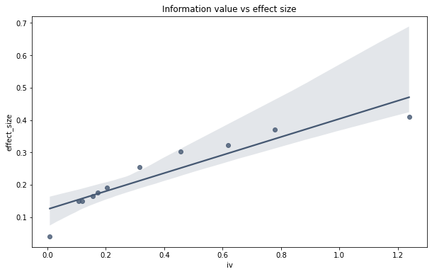

```
Pearson correlation: 0.93
Spearman correlation: 0.99
```

```python
df_analysis_sign = df_analysis[df_analysis['p-value']<0.05]

fig, ax = plt.subplots(figsize=(10,6))
sns.regplot(x='iv', y='effect_size', data=df_analysis_sign, color='#455872')
ax.set_title('Information value vs effect size')
plt.show()

print('Pearson correlation: %0.2f' % df_analysis_sign['iv'].corr(df_analysis_sign['effect_size']))
print('Spearman correlation: %0.2f' % df_analysis_sign['iv'].corr(df_analysis_sign['effect_size'], method='spearman'))
```

# 5. IV DAN WOE

Information value (IV) dan Weight Of Evidence (WOE) adalah teknik sederhana dan kuat untuk melakukan analisis relevansi atribut. Kedua teknik ini menyediakan kerangka kerja yang bagus untuk analisis eksplorasi dan telah digunakan secara luas di dunia perbankan dalam hal credit risk selama beberapa dekade.

#### INFORMATION VALUE (IV)

Information Value memberikan ukuran seberapa baik variabel X mampu membedakan antara yang "baik" dengan "buruk“ di beberapa variabel target Y. Tujuannya yaitu jika variabel X memiliki Nilai Informasi yang rendah, mungkin tidak cukup kuat untuk mengklasifikasikan variabel target tersebut, oleh karena itu biasanya fitur tersebut dihilangkan

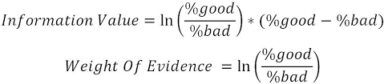

#### WEIGHT OF EVIDENCE (WOE)

Weight Of evidence menunjukkan kekuatan prediksi dari variabel independen dalam kaitannya dengan variabel dependen, umumnya digambarkan sebagai ukuran pemisahan pelanggan yang baik dan buruk.

- "Pelanggan Buruk" mengacu pada pelanggan yang gagal membayar pinjaman.
- "Pelanggan Baik" mengacu pada pelanggan yang membayar kembali pinjaman.

[figure not shown]

Objek dasar dalam analisis IV & WOE adalah fitur tunggal. Ada dua jenis fitur: Category dan Continous Buatlah objek fitur dengan instance kelas CategoricalFeature dan ContinousFeature

```python
feat_gender = CategoricalFeature(df, 'gender')
feat_charges = ContinuousFeature(df, 'totalCharges')
feat_contract = CategoricalFeature(df, 'contract')
feat_tenure = ContinuousFeature(df, 'tenure')
```

```python
feats_manual = [feat_gender, feat_charges, feat_contract, feat_tenure]
```

```python
feats_dict = {}

for col in [c for c in df.columns if c != 'label']:
    if is_numeric_dtype(df[col]):
        feats_dict[col] = ContinuousFeature(df, col)
    else:
        feats_dict[col] = CategoricalFeature(df, col)

feats = list(feats_dict.values())
```

Atribut dan method (IV() ):

1. group_by_feature(feature), menampilkan nilai ke bentuk dataframe dengan jumlah pengamatan yang pelanggan yang baik dan pelanggan yang buruk
2. calculate_iv(feature), menampilkan nilai ke bentuk dataframe dengan (dengan penjumlahan WOE dan IV) dan IV untuk fitur tersebut
3. draw_woe(feature), menampilkan gambar / chart dengan visualisasi nilai WOE dari fitur tersebut
4. interpretation(iv_value), menampilkan nilai predictive power (kekuatan prediksi) berdasarkan input IV dari fitur tersebut
5. interpret_iv(feature), menampilkan nilai predictive power (kekuatan prediksi) berdasarkan IV dari fitur tersebut
6. print_iv(feature), mencetak interpretasi dari IV dari fitur tersebut

```python
iv.group_by_feature(feat_charges)
```

[output not shown]

```python
iv_df, iv_value = iv.calculate_iv(feat_gender)
display(iv_df)
print('Information value: ', iv_value)
```

|  | gender | count | good | bad | perc_good | perc_bad | perc_diff | woe | iv |
| --- | --- | --- | --- | --- | --- | --- | --- | --- | --- |
| 0 | Female | 3488 | 2549 | 939 | 0.492656 | 0.502408 | -0.009752 | -0.019602 | 0.000191 |
| 1 | Male | 3555 | 2625 | 930 | 0.507344 | 0.497592 | 0.009752 | 0.019409 | 0.000189 |

```
Information value:  0.000380436636119779
```

[figure not shown]

```python
iv.draw_woe(feat_charges)
```

```python
print('%s is a %s predictor.' % (feat_charges.feature.capitalize(), iv.interpret_iv(feat_charges)))
print('A feature with IV = 0.2 is a %s predictor.' % iv.interpretation(0.2))
print()
iv.print_iv(feat_charges)
```

```
Totalcharges is a strong predictor.
A feature with IV = 0.2 is a medium predictor.

Information value: 0.32
Totalcharges is a strong predictor
```

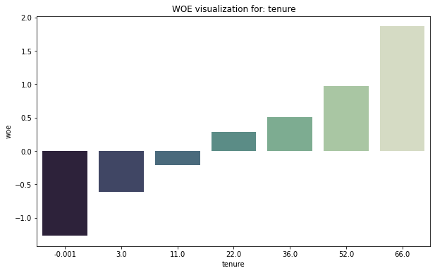

```python
iv.draw_woe(feats_dict['tenure'])
```

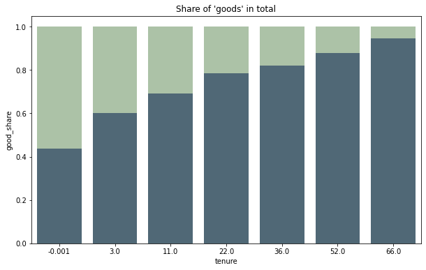

```python
df_tenure = iv.group_by_feature(feats_dict['tenure'])
df_tenure['total'] = 1
df_tenure['good_share'] = df_tenure['good'] / df_tenure['count']

fig, ax = plt.subplots(figsize=(10,6))
sns.barplot(x='tenure', y='total', data=df_tenure, color='#a9c6a3')
sns.barplot(x='tenure', y='good_share', data=df_tenure, color='#4a6a7c')
ax.set_title("Share of 'goods' in total")
plt.show()
```

### GABUNGAN IV, CHI SQUARE, DAN CRAMERS'V

```python
ar.analyze(feats, iv, interpretation=True)
```

|  | iv | iv_interpretation |
| --- | --- | --- |
| contract | 1.238560 | suspicious |
| tenure | 0.777926 | suspicious |
| onlineSecurity | 0.717777 | suspicious |
| techSupport | 0.699567 | suspicious |
| internetService | 0.617953 | suspicious |
| onlineBackup | 0.528634 | suspicious |
| deviceProtection | 0.499725 | strong |
| paymentMethod | 0.457109 | strong |
| bin | 0.457109 | strong |
| streamingMovies | 0.381374 | strong |
| streamingTV | 0.380462 | strong |
| totalCharges | 0.315230 | strong |
| paperlessBilling | 0.203068 | medium |
| monthlyCharges | 0.173429 | medium |
| dependents | 0.155488 | medium |
| partner | 0.118729 | medium |
| seniorCitizen | 0.105621 | medium |
| multipleLines | 0.008207 | useless |
| phoneService | 0.000745 | useless |
| gender | 0.000380 | useless |

```python
ar.analyze(feats, iv, s, interpretation=True)
```

|  | iv | p-value | effect_size | iv_interpretation | es_interpretation |
| --- | --- | --- | --- | --- | --- |
| contract | 1.238560 | 5.863038e-258 | 0.410116 | suspicious | strong |
| tenure | 0.777926 | 7.413515e-205 | 0.369846 | suspicious | medium |
| onlineSecurity | 0.717777 | 2.661150e-185 | 0.347400 | suspicious | medium |
| techSupport | 0.699567 | 1.443084e-180 | 0.342916 | suspicious | medium |
| internetService | 0.617953 | 9.571788e-160 | 0.322455 | suspicious | medium |
| onlineBackup | 0.528634 | 2.079759e-131 | 0.292316 | suspicious | medium |
| deviceProtection | 0.499725 | 5.505219e-122 | 0.281580 | strong | medium |
| paymentMethod | 0.457109 | 3.682355e-140 | 0.303359 | strong | medium |
| bin | 0.457109 | 3.682355e-140 | 0.303359 | strong | medium |
| streamingMovies | 0.381374 | 2.667757e-82 | 0.230951 | strong | medium |
| streamingTV | 0.380462 | 5.528994e-82 | 0.230502 | strong | medium |
| totalCharges | 0.315230 | 1.027752e-94 | 0.253656 | strong | medium |
| paperlessBilling | 0.203068 | 4.073355e-58 | 0.191498 | medium | weak |
| monthlyCharges | 0.173429 | 5.008386e-48 | 0.175864 | medium | weak |
| dependents | 0.155488 | 4.924922e-43 | 0.163870 | medium | weak |
| partner | 0.118729 | 2.139911e-36 | 0.150126 | medium | weak |
| seniorCitizen | 0.105621 | 1.510067e-36 | 0.150453 | medium | weak |
| multipleLines | 0.008207 | 3.464383e-03 | 0.040109 | useless | useless |
| phoneService | 0.000745 | 3.387825e-01 | 0.011398 | useless | useless |
| gender | 0.000380 | 4.865787e-01 | 0.008291 | useless | useless |

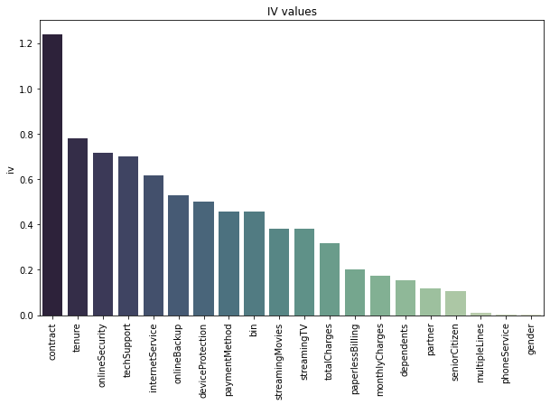

```python
ar.draw_iv(feats, iv)
```

```python
df_analysis = ar.analyze(feats, iv, s, interpretation=True)
display(df_analysis)
```

|  | iv | p-value | effect_size | iv_interpretation | es_interpretation |
| --- | --- | --- | --- | --- | --- |
| contract | 1.238560 | 5.863038e-258 | 0.410116 | suspicious | strong |
| tenure | 0.777926 | 7.413515e-205 | 0.369846 | suspicious | medium |
| onlineSecurity | 0.717777 | 2.661150e-185 | 0.347400 | suspicious | medium |
| techSupport | 0.699567 | 1.443084e-180 | 0.342916 | suspicious | medium |
| internetService | 0.617953 | 9.571788e-160 | 0.322455 | suspicious | medium |
| onlineBackup | 0.528634 | 2.079759e-131 | 0.292316 | suspicious | medium |
| deviceProtection | 0.499725 | 5.505219e-122 | 0.281580 | strong | medium |
| paymentMethod | 0.457109 | 3.682355e-140 | 0.303359 | strong | medium |
| bin | 0.457109 | 3.682355e-140 | 0.303359 | strong | medium |
| streamingMovies | 0.381374 | 2.667757e-82 | 0.230951 | strong | medium |
| streamingTV | 0.380462 | 5.528994e-82 | 0.230502 | strong | medium |
| totalCharges | 0.315230 | 1.027752e-94 | 0.253656 | strong | medium |
| paperlessBilling | 0.203068 | 4.073355e-58 | 0.191498 | medium | weak |
| monthlyCharges | 0.173429 | 5.008386e-48 | 0.175864 | medium | weak |
| dependents | 0.155488 | 4.924922e-43 | 0.163870 | medium | weak |
| partner | 0.118729 | 2.139911e-36 | 0.150126 | medium | weak |
| seniorCitizen | 0.105621 | 1.510067e-36 | 0.150453 | medium | weak |
| multipleLines | 0.008207 | 3.464383e-03 | 0.040109 | useless | useless |
| phoneService | 0.000745 | 3.387825e-01 | 0.011398 | useless | useless |
| gender | 0.000380 | 4.865787e-01 | 0.008291 | useless | useless |

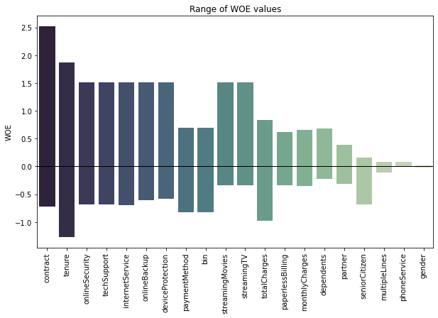

```python
ar.draw_woe_extremes(feats, iv)
```

```python
feats_dict_black = {}
df_black = df[df['internetService']!='No']
black_list = ['onlineSecurity', 'techSupport', 'onlineBackup', 'streamingTV', 'streamingMovies', 'deviceProtection']
for b in black_list:
    feats_dict_black[b] = CategoricalFeature(df_black, b)

feats_black = list(feats_dict_black.values())
```

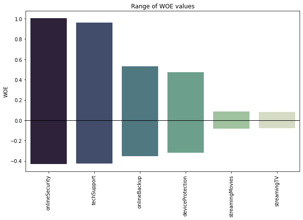

```python
ar.draw_woe_extremes(feats_black, iv)
```

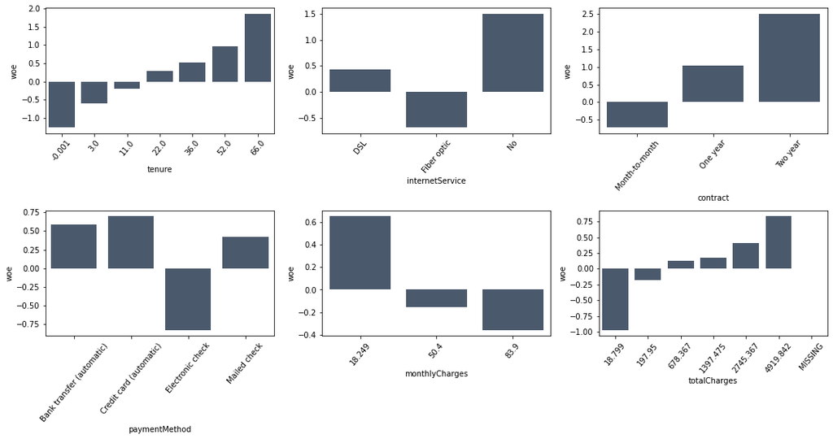

```python
f_draw = ['contract', 'tenure', 'internetService', 'paymentMethod', 'totalCharges', 'monthlyCharges', 'charges']
feats_draw = [v for k, v in feats_dict.items() if k in f_draw]
ar.draw_woe_multiplot(feats_draw, iv)
```

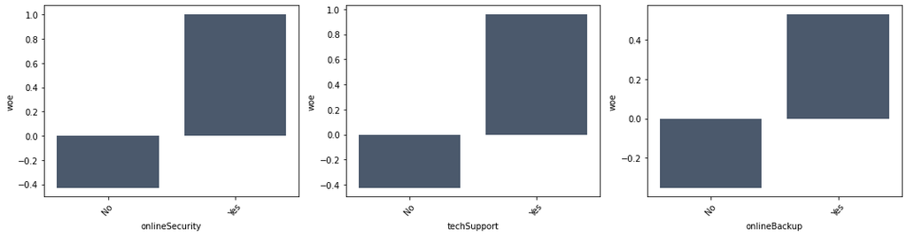

```python
f_black_draw = ['onlineSecurity', 'techSupport', 'onlineBackup']
feats_black_draw = [v for k, v in feats_dict_black.items() if k in f_black_draw]
ar.draw_woe_multiplot(feats_black_draw, iv)
```

### 6. VIF

Multikolinearitas dalam suatu model regresi dapat diketahui dengan menghitung nilai Variance Inflation Factor (VIF). VIF adalah suatu faktor yang mengukur seberapa besar kenaikan ragam dari koefisien penduga regresi dibandingkan terhadap variabel bebas yang orthogonal jika dihubungkan secara linear.

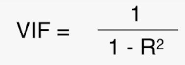

R-kuadrat adalah koefisien determinasi dalam regresi linier. Nilainya terletak antara 0 dan 1. Seperti yang kita lihat dari rumus, semakin besar nilai R- kuadrat, semakin besar VIF. Oleh karena itu, VIF yang lebih besar menunjukkan korelasi yang lebih besar. Hal ini sesuai dengan fakta bahwa nilai R-kuadrat yang lebih tinggi menunjukkan kolinearitas yang lebih kuat. Umumnya, nilai VIF di atas 5 menunjukkann multikolinearitas yang tinggi

```python
from statsmodels.stats.outliers_influence import variance_inflation_factor
df=pd.read_csv('train.csv', nrows=10000)
vif_data = pd.DataFrame()
vif_data["feature"] = df.columns
vif_data["VIF"] = [variance_inflation_factor(df.values, i) for i in range(len(df.columns))]
vif_data
```

|  | feature | VIF |
| --- | --- | --- |
| 0 | ID | 4.035893e+00 |
| 1 | var3 | 1.012140e+00 |
| 2 | var15 | 1.096692e+01 |
| 3 | imp_ent_var16_ult1 | 1.262407e+00 |
| 4 | imp_op_var39_comer_ult1 | 4.210939e+12 |
| ... | ... | ... |
| 366 | saldo_medio_var44_hace3 | 1.861470e+02 |
| 367 | saldo_medio_var44_ult1 | 7.098352e+03 |
| 368 | saldo_medio_var44_ult3 | 5.919613e+03 |
| 369 | var38 | 1.559770e+00 |
| 370 | TARGET | 1.108855e+00 |

371 rows × 2 columns

```python
feature = vif_data[vif_data['VIF'] > 150]
```

```python
feature['feature'].unique()
```

```
array(['imp_op_var39_comer_ult1', 'imp_op_var39_comer_ult3',
       'imp_op_var40_comer_ult1', 'imp_op_var40_comer_ult3',
       'imp_op_var40_efect_ult1', 'imp_op_var40_efect_ult3',
       'imp_op_var40_ult1', 'imp_op_var41_comer_ult1',
       'imp_op_var41_comer_ult3', 'imp_op_var41_efect_ult1',
       'imp_op_var41_efect_ult3', 'imp_op_var41_ult1',
       'imp_op_var39_efect_ult1', 'imp_op_var39_efect_ult3',
       'imp_op_var39_ult1', 'ind_var1_0', 'ind_var1', 'ind_var5_0',
       'ind_var5', 'ind_var6_0', 'ind_var6', 'ind_var8_0', 'ind_var8',
       'ind_var12', 'ind_var13_0', 'ind_var13_corto_0', 'ind_var13_corto',
       'ind_var13_largo', 'ind_var13', 'ind_var14_0', 'ind_var14',
       'ind_var17_0', 'ind_var17', 'ind_var20_0', 'ind_var20',
       'ind_var24_0', 'ind_var24', 'ind_var25_cte', 'ind_var26_0',
       'ind_var26_cte', 'ind_var26', 'ind_var25_0', 'ind_var25',
       'ind_var29_0', 'ind_var29', 'ind_var30_0', 'ind_var31',
       'ind_var32_cte', 'ind_var32_0', 'ind_var32', 'ind_var33_0',
       'ind_var33', 'ind_var37_0', 'ind_var37', 'ind_var39_0',
       'ind_var40_0', 'ind_var40', 'ind_var41_0', 'ind_var39',
       'ind_var44_0', 'ind_var44', 'num_var1_0', 'num_var1', 'num_var4',
       'num_var5_0', 'num_var5', 'num_var6_0', 'num_var6', 'num_var8_0',
       'num_var8', 'num_var12_0', 'num_var12', 'num_var13_0',
       'num_var13_corto_0', 'num_var13_corto', 'num_var13_largo_0',
       'num_var13_largo', 'num_var13', 'num_var14_0', 'num_var14',
       'num_var17_0', 'num_var17', 'num_var20_0', 'num_var20',
       'num_var24_0', 'num_var24', 'num_var26_0', 'num_var26',
       'num_var25_0', 'num_var25', 'num_op_var40_hace2',
       'num_op_var40_hace3', 'num_op_var40_ult1', 'num_op_var40_ult3',
       'num_op_var41_hace2', 'num_op_var41_hace3', 'num_op_var41_ult1',
       'num_op_var41_ult3', 'num_op_var39_hace2', 'num_op_var39_hace3',
       'num_op_var39_ult1', 'num_op_var39_ult3', 'num_var29_0',
       'num_var29', 'num_var30_0', 'num_var30', 'num_var31_0',
       'num_var31', 'num_var32_0', 'num_var32', 'num_var33_0',
       'num_var33', 'num_var35', 'num_var37_0', 'num_var37',
       'num_var39_0', 'num_var40_0', 'num_var40', 'num_var41_0',
       'num_var39', 'num_var42_0', 'num_var42', 'num_var44_0',
       'num_var44', 'saldo_var1', 'saldo_var5', 'saldo_var6',
       'saldo_var8', 'saldo_var12', 'saldo_var13_corto',
       'saldo_var13_largo', 'saldo_var13', 'saldo_var14', 'saldo_var17',
       'saldo_var20', 'saldo_var24', 'saldo_var26', 'saldo_var25',
       'saldo_var29', 'saldo_var30', 'saldo_var31', 'saldo_var32',
```

[output cut: 23 more lines]

```
       'num_op_var41_comer_ult3', 'num_op_var41_efect_ult1',
       'num_op_var41_efect_ult3', 'num_op_var39_efect_ult1',
       'num_op_var39_efect_ult3', 'num_reemb_var13_ult1',
       'num_trasp_var17_in_ult1', 'num_trasp_var33_in_ult1',
       'num_venta_var44_ult1', 'num_var45_hace2', 'num_var45_hace3',
       'num_var45_ult1', 'num_var45_ult3', 'saldo_medio_var12_ult1',
       'saldo_medio_var13_corto_ult1', 'saldo_medio_var13_corto_ult3',
       'saldo_medio_var17_hace2', 'saldo_medio_var17_hace3',
       'saldo_medio_var17_ult1', 'saldo_medio_var17_ult3',
       'saldo_medio_var29_hace2', 'saldo_medio_var29_ult1',
       'saldo_medio_var29_ult3', 'saldo_medio_var33_hace2',
       'saldo_medio_var33_hace3', 'saldo_medio_var33_ult1',
       'saldo_medio_var33_ult3', 'saldo_medio_var44_hace2',
       'saldo_medio_var44_hace3', 'saldo_medio_var44_ult1',
       'saldo_medio_var44_ult3'], dtype=object)
```

Nama-nama diatas adalah yang cenderung multicollinearity

### 7. INFORMATION GAIN

Mengukur seberapa banyak informasi yang diperoleh dari suatu fitur untuk prediksi kategori dengan mengetahui kemunculan atau tidaknya sebuah term dalam sebuah dokumen

```python
#Skema 1: Melibatkan data numerik
from sklearn.ensemble import RandomForestClassifier
from sklearn.preprocessing import StandardScaler
scaler=StandardScaler()
X_std=scaler.fit_transform(X)
X_std=pd.DataFrame(X_std,columns=X.columns)
```

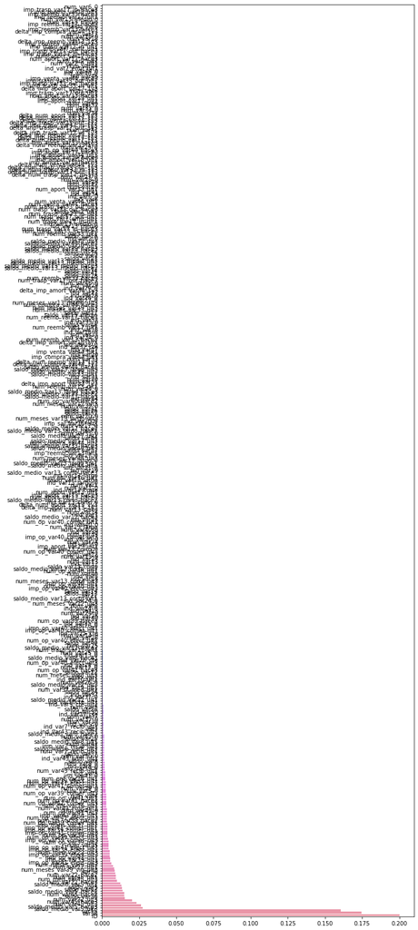

```python
rf = RandomForestClassifier(n_estimators=100)
rf.fit(X_std,y)
fig=plt.figure(figsize=(10,30))
sorted_idx = rf.feature_importances_.argsort()
sns.barplot(y=X_std.columns[sorted_idx], x=rf.feature_importances_[sorted_idx])
```

```python
from sklearn.feature_selection import SelectFromModel

selector=SelectFromModel(estimator=rf).fit(X_std,y)
selector.get_support()
```

```
array([ True, False,  True, False,  True,  True, False, False, False,
       False, False,  True,  True,  True,  True,  True,  True,  True,
        True, False, False, False, False, False, False, False, False,
       False, False, False, False, False, False, False, False, False,
       False, False, False, False, False, False, False, False, False,
       False, False, False, False, False, False, False, False, False,
       False, False, False, False, False, False, False, False, False,
       False, False, False, False, False, False, False, False, False,
       False, False, False, False, False, False, False, False, False,
       False, False, False, False, False, False, False, False,  True,
       False, False, False, False, False, False, False, False, False,
       False, False, False, False, False, False, False, False, False,
       False, False, False, False, False, False, False, False, False,
       False, False, False, False, False, False, False,  True, False,
        True,  True,  True, False,  True,  True, False, False, False,
       False, False, False, False, False, False, False, False, False,
       False, False, False, False,  True, False, False, False,  True,
       False, False,  True, False, False, False, False, False, False,
       False, False, False,  True, False, False, False, False, False,
       False, False, False, False, False, False, False, False, False,
       False, False, False,  True, False, False, False, False, False,
       False, False,  True, False, False,  True, False, False, False,
       False, False, False, False, False, False, False, False, False,
       False, False, False, False, False, False, False, False, False,
       False, False, False, False, False, False, False, False, False,
       False, False, False, False, False, False, False, False, False,
       False, False, False, False, False, False, False,  True,  True,
       False, False, False, False, False, False, False, False, False,
       False, False, False, False, False, False, False, False, False,
       False, False, False, False, False, False, False, False, False,
       False, False, False, False, False,  True,  True,  True,  True,
        True,  True,  True, False, False, False, False, False, False,
       False, False,  True, False,  True, False, False, False, False,
       False,  True,  True, False,  True, False,  True, False, False,
       False, False, False, False, False,  True, False, False, False,
       False, False, False, False, False, False, False, False, False,
        True,  True,  True,  True, False,  True,  True,  True,  True,
       False, False, False, False, False, False, False, False, False,
       False, False, False, False, False, False, False, False, False,
       False, False, False, False, False, False, False, False, False,
       False, False, False, False, False, False, False, False, False,
        True])
```

```python
features_imp=pd.DataFrame({'Features':X_std.columns,'Importance':rf.feature_importances_}).sort_values('Importance').reset_index(drop=True)
features_imp['cumulative']=features_imp.Importance.cumsum()
```

```python
features_imp.sort_values('Importance', ascending=False)
```

|  | Features | Importance | cumulative |
| --- | --- | --- | --- |
| 369 | ID | 0.199998 | 1.000000 |
| 368 | var38 | 0.174686 | 0.800002 |
| 367 | var15 | 0.160507 | 0.625316 |
| 366 | saldo_medio_var5_ult3 | 0.027562 | 0.464809 |
| 365 | saldo_medio_var5_hace3 | 0.026337 | 0.437247 |
| ... | ... | ... | ... |
| 98 | saldo_medio_var29_hace3 | 0.000000 | 0.000000 |
| 99 | saldo_medio_var29_hace2 | 0.000000 | 0.000000 |
| 100 | saldo_var29 | 0.000000 | 0.000000 |
| 101 | ind_var2 | 0.000000 | 0.000000 |
| 0 | num_var6_0 | 0.000000 | 0.000000 |

370 rows × 3 columns